# SanFranciscoBay bike-share demand

## Investigation Overview

In my investigation I was interested in figuring out if there are any patterns in the characteristics and behavior of the users that will impact the demand of bike-share at certain moments in time.  
I find this important because, as a service provider, you need to know when are your peaks in the demand so you make sure the bikes are available to the customers.

## Dataset Overview

There are around 175k bike ride logs with 16 features regarding duration, moment/location of the start/end of the trip, plus user details – type of user subscription, if the subscription is "Bike Share for all", the user’s year of birth and gender. The rides in the dataset are from February 2019 in San Francisco Bay area. I also created extra features derived from the dataset like - flagging the city (San Francisco, Oakland or San Jose), moment of the day when a ride had started and whether it happened during a work day or the weekend. Around 8000 records with whether missing data, outliers or wrong information were discarded.

## Distribution of the BikeShare demand during the day

For this I used the number of rides started each minute during the day. The demand has a bimodal distribution with the 2 peaks around 8:30am and 6:30pm, which makes sense since probably those are the times when people go to work and back home. There is also a consistent plateau between 12pm and 3pm, quite uniformly distributed.

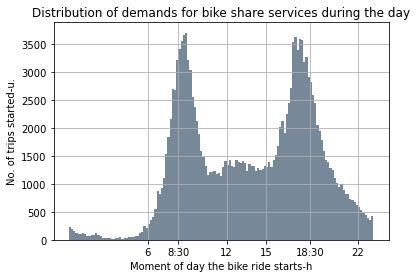

```python
# plot the distribution of moments of the day the trip starts
bike2.start_mom.hist(bins=np.arange(0,1400,10),color='lightslategrey')
plt.xticks([360,500,720,900,1100,1320], ['6','8:30','12', '15','18:30','22'])

plt.title('Distribution of demands for bike share services during the day')
plt.xlabel('Moment of day the bike ride starts-h');
plt.ylabel('No. of trips started-u.');
```

## Distribution of the Users Ages

The age is skewed to right, but that is to be expected since those younger than ~18 could not be customers. The mean is around 34, higher than the median of 32 due to the tail towards older ages. However, most users appear to be between 20 and 40 years of age.

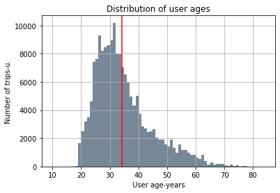

```python
# plot the distribution of age
bike2.age.hist(bins=np.arange(10,85,1), color='lightslategrey')
plt.axvline(bike2.age.mean(),color='r')
plt.title('Distribution of user ages')
plt.xlabel('User age-years');
plt.ylabel('Number of trips-u.');
```

## BikeShare demand during the day vs Age of User

There seems to be a bit of a pattern regarding how different age groups demand the bike-share service: the people over 60 start their trips in a more uniform pattern (without the 2 peaks we saw in the overall view). This is understandable since many are retired and don’t have a schedule to follow. The peaks are very visible for the ages between 35 and 60 – probably these are the professionals commuting in the morning and evening towards work and back. The youngest ones seem to demand the service in an uniform pattern during the day.

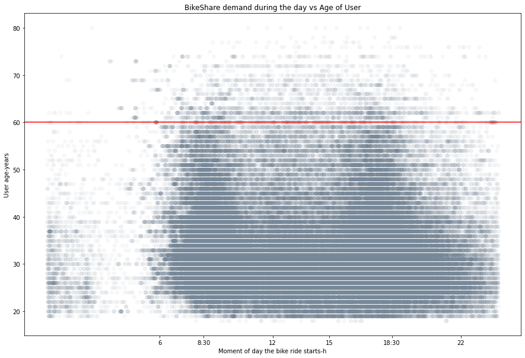

```python
# Plot the enlarged view of start moment vs age
plt.figure(figsize=(15,10))
plt.scatter(data=bike2,y="age",x="start_mom",alpha=0.05,color='lightslategrey')

plt.xticks([360,500,720,900,1100,1320], ['6','8:30','12', '15','18:30','22'])
plt.axhline(60,color='red')
plt.title('BikeShare demand during the day vs Age of User')
plt.ylabel('User age-years')
plt.xlabel('Moment of day the bike ride starts-h');
```

## BikeShare demand during the day vs Age by Location and User Type

The Oakland and San Francisco distributions seem pretty similar, Oakland having also a small peak for the age in the early 20’s.

San Jose shows a very different story – the distribution of demand is not bimodal and is mostly uniform during the day. The age is a lot less varied and mostly concentrated around the mid-20s, as opposed to the other 2 cities where the highest frequency is of early 30’s.

Visually, the user type has a similar influence as the location cluster. The most striking similarity is between the San Jose distributions and the users with the discounted subscription (Bikes4All).

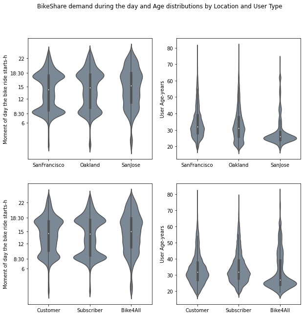

```python
# create violin plots to see the distribution of age and start of the trip,
# differentiated by the categorical variables



fig=plt.figure(figsize=(10,10) )
fig.suptitle('BikeShare demand during the day and Age distributions by Location and User Type')

ax1=plt.subplot(221)
ax1=sb.violinplot(data = bike2, x = 'start_cluster', y = 'start_mom',
               color = 'lightslategrey')
ax1.set_yticks([360,500,720,900,1100,1320])
ax1.set_yticklabels(['6','8:30','12', '15','18:30','22'])
ax1=plt.ylabel('Moment of day the bike ride starts-h')
ax1=plt.xlabel('')

ax2=plt.subplot(222)
ax2=sb.violinplot(data = bike2, x = 'start_cluster', y = 'age',
               color = 'lightslategrey')

ax2=plt.ylabel('User Age-years')
ax2=plt.xlabel('')

ax3=plt.subplot(223)
ax3=sb.violinplot(data = bike2, x = 'user_type', y = 'start_mom',
               color = 'lightslategrey')
ax3.set_yticks([360,500,720,900,1100,1320])
ax3.set_yticklabels(['6','8:30','12', '15','18:30','22'])
ax3=plt.ylabel('Moment of day the bike ride starts-h')
ax3=plt.xlabel('')

ax4=plt.subplot(224)
ax4=sb.violinplot(data = bike2, x = 'user_type', y = 'age',
               color = 'lightslategrey')

ax4=plt.ylabel('User Age-years')
ax4=plt.xlabel('')


plt.show();
```

## User Types proportion by Location

The similarity between the patterns shown by location and user type is not by chance: 78% of the trips in San Jose are done by subscribers from the "Bike Share For All" membership – a discounted subscription.  
The other 2 cities have the majority of the trips done by regular subscribers.  
So this is why the location and user types had similar influence on the demand pattern during the day.

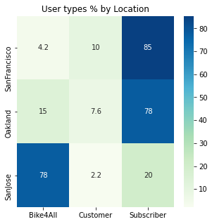

```python
# plot a heatmap of proportion of user types by location

# create a summary table with location on rows and count of users as columns

hm=bike2[['start_cluster','user_type']].copy(deep=True)
subscribers=hm.pivot_table(index='start_cluster', columns='user_type',
                        aggfunc=len, fill_value=0)
subscribers['Bike4All2']=subscribers['Bike4All']*100/(subscribers['Bike4All']+subscribers['Customer']+subscribers['Subscriber'])
subscribers['Customer2']=subscribers['Customer']*100/(subscribers['Bike4All']+subscribers['Customer']+subscribers['Subscriber'])
subscribers['Subscriber2']=subscribers['Subscriber']*100/(subscribers['Bike4All']+subscribers['Customer']+subscribers['Subscriber'])
subscribers.drop(columns=['Bike4All','Customer','Subscriber'],inplace=True)
subscribers.rename(columns={'Bike4All2':'Bike4All','Customer2':'Customer','Subscriber2':'Subscriber'},inplace=True)

# plot the heatmap
fig = plt.figure(figsize=(5,5))
r = sb.heatmap(subscribers, cmap='GnBu', annot = True)
r.set_title("User types % by Location")
plt.xlabel('')
plt.ylabel('') ;
```

## Age and User Types demand during *work days* in each Location

Because in San Francisco we have mostly regular Subscribers, with a median age in their early 30s, they are probably professionals that are driving the peak in demand at 8:30 and 18:30.

For San Jose the majority of rides are done by discount subscribers, in their late 20’s and they do not drive peaks in the demand during the day- they could be university students.

Oakland is a bit of a mix between the 2: the discounted subscribers are similar to the ones in San Jose – in their 20’s - as opposed to San Francisco, where the "Bike Share For All" subscribers are almost any age.  
These users have a smooth demand during the day like in San Jose.

Still, the majority of users in Oakland are regular subscribers and they also drive the 8:30 and 18:30 peaks during the week – in this respect Oakland is more similar to San Francisco.

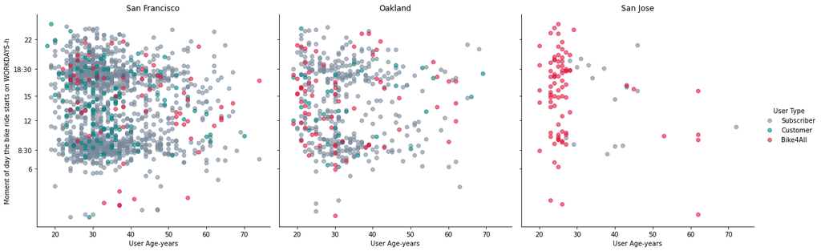

```python
bike_samp = bike2[bike2.wk_day=='WorkWeek'].sample(n=2000, axis=0)
# create faceted heat maps on levels of the cut variable
color_dict = dict({'Subscriber':'lightslategrey',
                  'Bike4All':'crimson',
                  'Customer': 'teal'})
g = sb.FacetGrid(data = bike_samp, col = 'start_cluster', hue='user_type', col_wrap = 3, height= 5.5, palette = color_dict)
g.map(plt.scatter,  'age','start_mom', alpha =0.6)
g.set_ylabels('Moment of day the bike ride starts on WORKDAYS-h')
g.set_xlabels('User Age-years')
g.add_legend(title='User Type')
plt.yticks([360,500,720,900,1100,1320], ['6','8:30','12', '15','18:30','22'])
for ax, title in zip(g.axes.flat, ['San Francisco', 'Oakland', 'San Jose']):
    ax.set_title(title)
plt.show();
```

## Age and User Types demand during *weekends* in each Location

During the weekends the peaks get smoothed out towards the mid of the day and the user type has a smaller influence on the demand. For San Francisco we can see an increase in the demand by the customers with no subscription which is probably driven by leisure time.

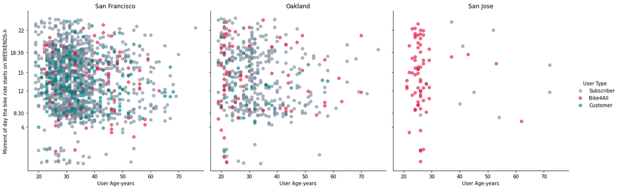

```python
bike_samp = bike2[bike2.wk_day=='WeekEnd'].sample(n=2000, axis=0)
# create faceted heat maps on levels of the cut variable
color_dict = dict({'Subscriber':'lightslategrey',
                  'Bike4All':'crimson',
                  'Customer': 'teal'})
g = sb.FacetGrid(data = bike_samp, col = 'start_cluster', hue='user_type', col_wrap = 3, height= 5.5, palette = color_dict)
g.map(plt.scatter,  'age','start_mom', alpha =0.6)
g.set_ylabels('Moment of day the bike ride starts on WEEKENDS-h')
g.set_xlabels('User Age-years')
g.add_legend(title = 'User Type')
plt.yticks([360,500,720,900,1100,1320], ['6','8:30','12', '15','18:30','22'])

for ax, title in zip(g.axes.flat, ['San Francisco', 'Oakland', 'San Jose']):
    ax.set_title(title)

plt.show();
```

## San Francisco Bay hot spots

We saw that the risk of having peaks of bike-share demands is the highest in San Francisco and, to a smaller extent, in Oakland.  
This is driven by the high proportion of demands from the users that are in their 30’s, have a full subscription and use the ride sharing service to commute to work and back home.

On the map it seems that the hotspot stations are in the San Francisco city center’s main artery – Market street - and also around the docks and the railway station.

```python
basemap=folium.Map(location=[37.804560, -122.311094], zoom_start=12.45)
plotdata=folium.map.FeatureGroup()

for lat, lon, trips, name in zip(stat['lat'],stat['lon'], stat['trips'],stat['start_station_name']):
    plotdata.add_child(
        folium.CircleMarker(
        [lat,lon],
        radius=0.0035*trips,
        popup=name,
        color='red',
        fill=True,
        fill_color='red',
        fill_opacity=0.6))

basemap.add_child(plotdata)
```

Make this Notebook Trusted to load map: File -> Trust Notebook

[interactive chart not shown]